# Assignment MP1

Srishti Patil

2024-10-15

```r
library(readr)
library(fpp)
library(fpp2)
library(forecast)
```

#Loading dataset

```r
flightVolume <- read_csv("C:/Users/Srishti/Desktop/FALL24/BF/Tests/flightVolume.csv")
```

```
## ──────────────────────────────────────────────────────── Delimiter: "," dbl
## (6): ...1, permanent, reslong, vislong, resshort, visshort
```

```r
head(flightVolume)
```

```
## # A tibble: 6 × 6
##    ...1 permanent reslong vislong resshort visshort
##   <dbl>     <dbl>   <dbl>   <dbl>    <dbl>    <dbl>
## 1     1      2.17    7.39    1.87     75.8     66.2
## 2     2      2.06    5.13    1.42     54.7     49.4
## 3     3      2.66    6.35    1.67     85       46.8
## 4     4      2.32    5.64    1.42     74.6     41
## 5     5      2.75    6.73    1.77    104.      43
## 6     6      2       5.17    1.42     82       28.4
```

1. Create Timeseries

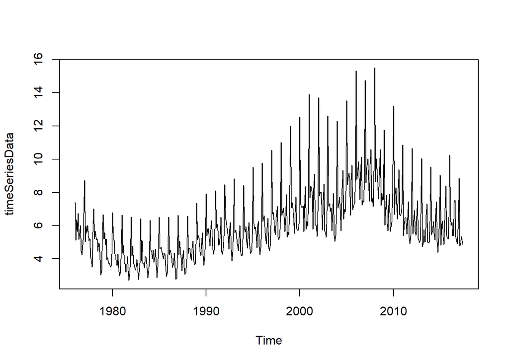

```r
timeSeriesData <- ts(flightVolume$reslong, start=c(1976, 1), frequency=12)
plot(timeSeriesData)
```

2. Verify how much history to include in your analysis.

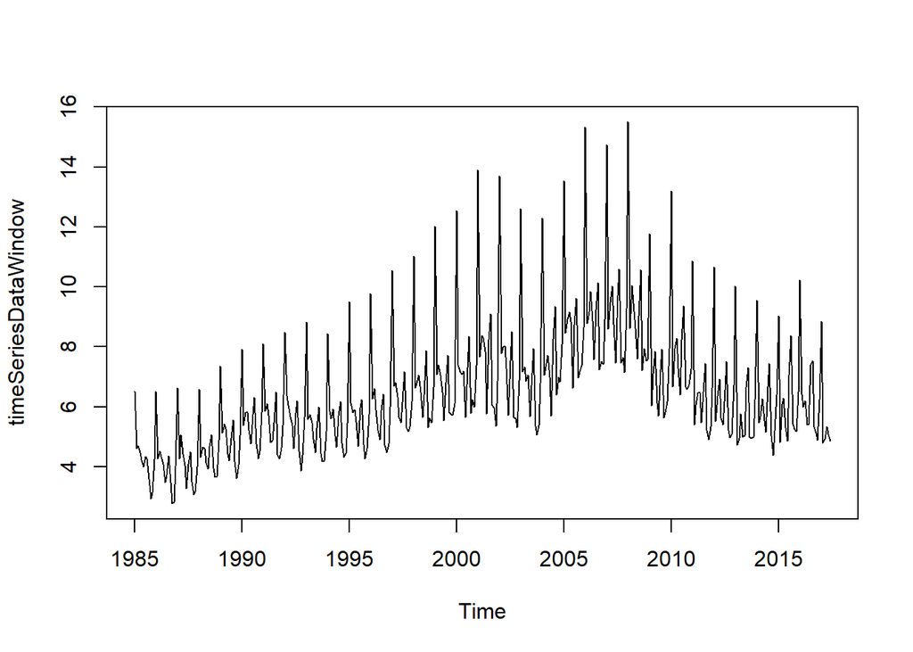

```r
timeSeriesDataWindow <- window(timeSeriesData, start = c(1985, 1))
plot(timeSeriesDataWindow)
```

3. Hypothesize if the dataset has trend, seasonality, or both. We can see there is an upward trend in the data, particularly visible from the late 1990s through the mid-2000s. This suggests that the underlying level of the time series is increasing over time. The recurring spikes in the data at regular intervals indicates seasonality. These peaks appear to happen consistently, suggesting a repetitive pattern, possibly yearly or within a specific time period. Hence, the dataset seems to show both seasonality—regular periodic fluctuations—and trend, or an increasing movement over time.
4. Verify using Acf

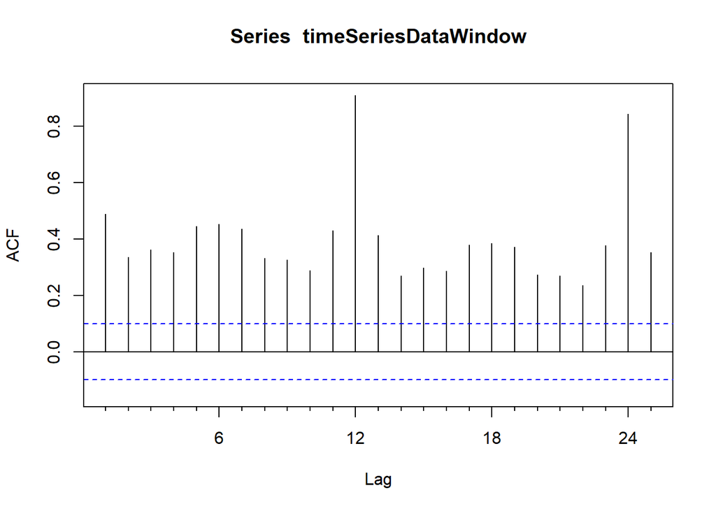

```r
Acf(timeSeriesDataWindow)
```

We can say that the dataset indicates tred when the autocorrelations decay slowly over many lags. This ACF plot shows the gradual decrease of autocorrelations but still stays positive for several lags. Hence, the ACF plot verifies the Trend nature of the data.

We can say the plot is seasonal when the spkies are repeating at regular intervals. In the above ACF plot the spikes lags around 12 and 24 which makes it a recuring pattern suggesting an annual pattern. Hence, suggesting the seasonality of the plot.

5. Verify using decomposition

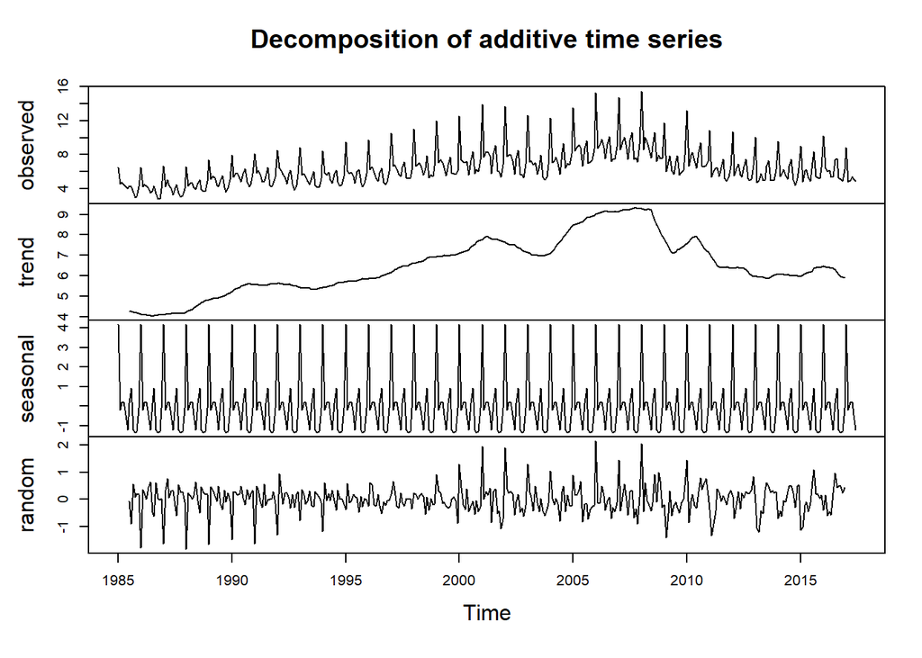

```r
decomposed_data <- decompose(timeSeriesDataWindow)
plot(decomposed_data)
```

The seasonal component exhibits cycles that repeat at regular intervals and are recognizable by frequent, strong peaks and troughs. Throughout the whole time span, this regular pattern is present at every time point. Hence, indicating seasonality.

6. Chose an accuracy measure
7. Create a forecast model for the next 12 months. Include Naive, Average, Exponential Smoothing, HoltWinters, and Decomposition (both types).

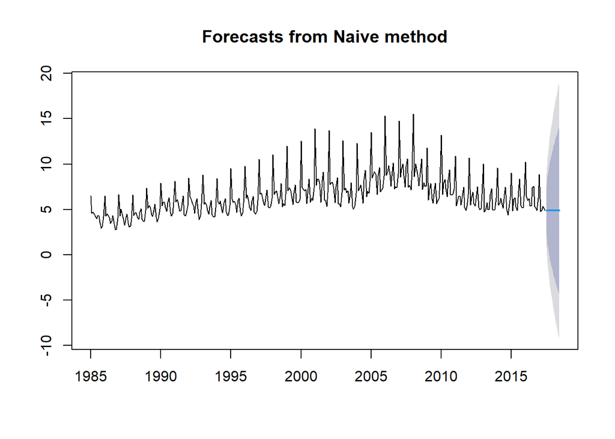

```r
# Naive forecast
naive_forecast <- naive(timeSeriesDataWindow, h=12)
plot(naive_forecast)
```

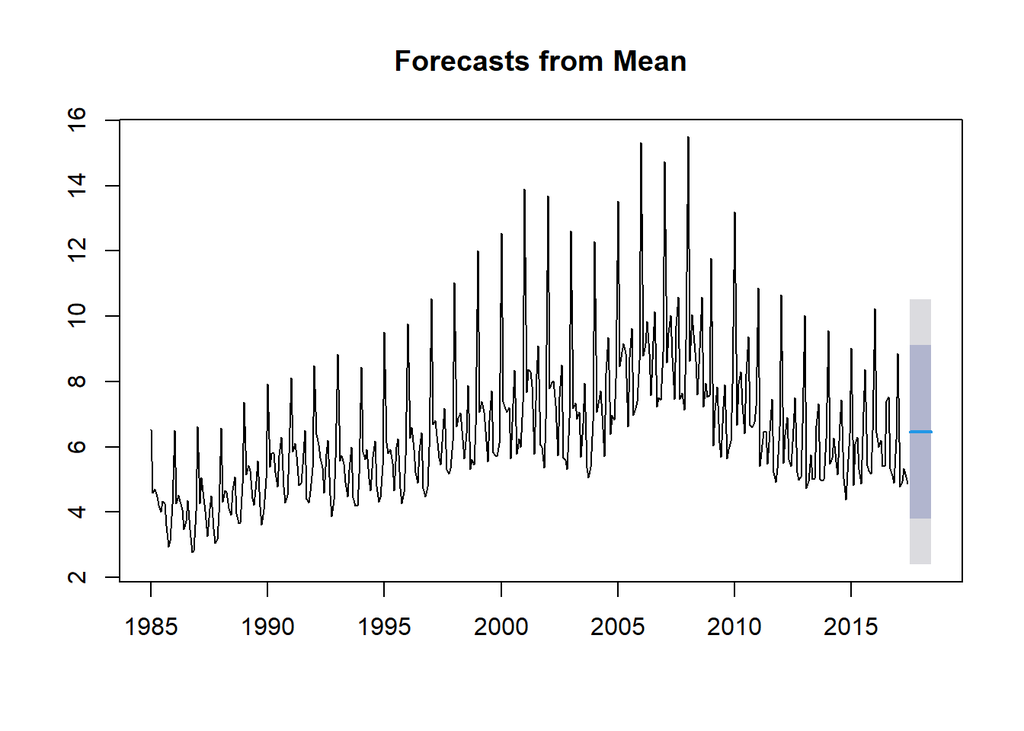

```r
# Mean/average method
mean_forecast <- meanf(timeSeriesDataWindow, h=12)
plot(mean_forecast)
```

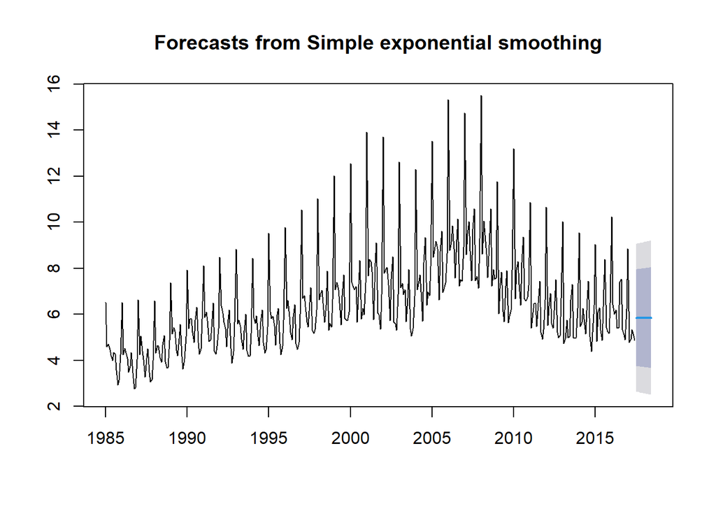

```r
# Exponential Smoothing
ses_forecast <- ses(timeSeriesDataWindow, h=12)
plot(ses_forecast)
```

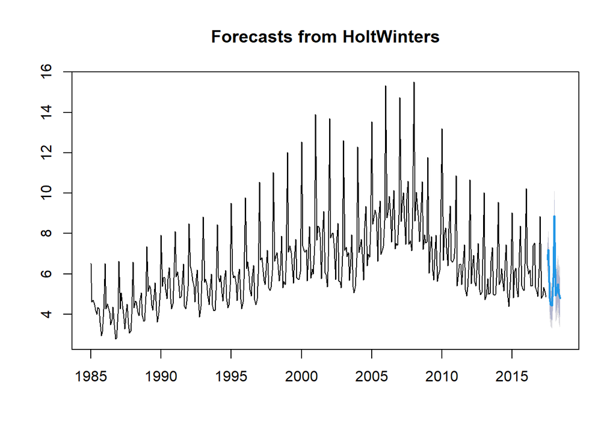

```r
# Holt-Winters forecast
hw_forecast <- HoltWinters(timeSeriesDataWindow)
hw_forecast_future <- forecast(hw_forecast, h=12)
plot(hw_forecast_future)
```

```r
# Moving Averages
MA5_forecast <- ma(timeSeriesDataWindow,order=12)
print(MA5_forecast)
```

```
##           Jan      Feb      Mar      Apr      May      Jun      Jul      Aug
## 1985       NA       NA       NA       NA       NA       NA 4.251250 4.236667
## 1986 4.116250 4.094167 4.092917 4.081250 4.060833 4.038333 4.034167 4.039167
## 1987 4.085000 4.106250 4.113333 4.126250 4.152917 4.165833 4.162083 4.162500
## 1988 4.233333 4.281250 4.324167 4.368333 4.415417 4.474583 4.544167 4.610833
## 1989 4.822917 4.855000 4.885000 4.892500 4.906667 4.929167 4.959167 4.992917
## 1990 5.226667 5.290417 5.345833 5.398333 5.444167 5.494167 5.533750 5.561250
## 1991 5.563333 5.560000 5.553333 5.538333 5.543333 5.530417 5.527917 5.565000
## 1992 5.614167 5.615000 5.607500 5.595417 5.568333 5.570417 5.597083 5.578333
## 1993 5.433333 5.404167 5.392083 5.401667 5.407083 5.378750 5.341667 5.336667
## 1994 5.416250 5.440833 5.462917 5.482917 5.498750 5.520417 5.576667 5.632917
## 1995 5.711250 5.726250 5.727083 5.722500 5.726667 5.745833 5.769167 5.785833
## 1996 5.850833 5.854167 5.861250 5.870000 5.885833 5.903333 5.946250 5.996250
## 1997 6.176667 6.234167 6.289167 6.342083 6.394167 6.425000 6.452917 6.470417
## 1998 6.613750 6.638333 6.667500 6.686250 6.710417 6.735833 6.796667 6.855833
```

[output cut: 53 more lines]

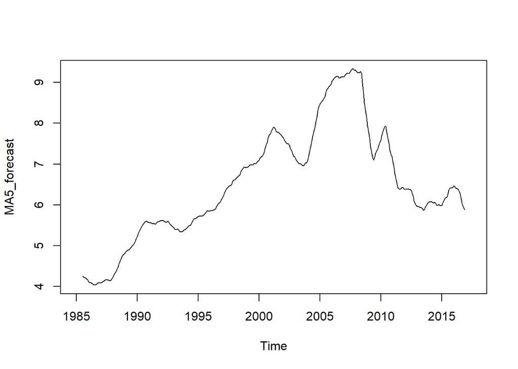

```r
plot(MA5_forecast)
```

```r
# decomposition
decomp_add <- decompose(timeSeriesDataWindow, type="additive")
decomp_mult <- decompose(timeSeriesDataWindow, type="multiplicative")

# Decomposition Forecasts using trend component
decomp_add_forecast <- forecast(decomp_add$trend, h=12)
decomp_mult_forecast <- forecast(decomp_mult$trend, h=12)
```

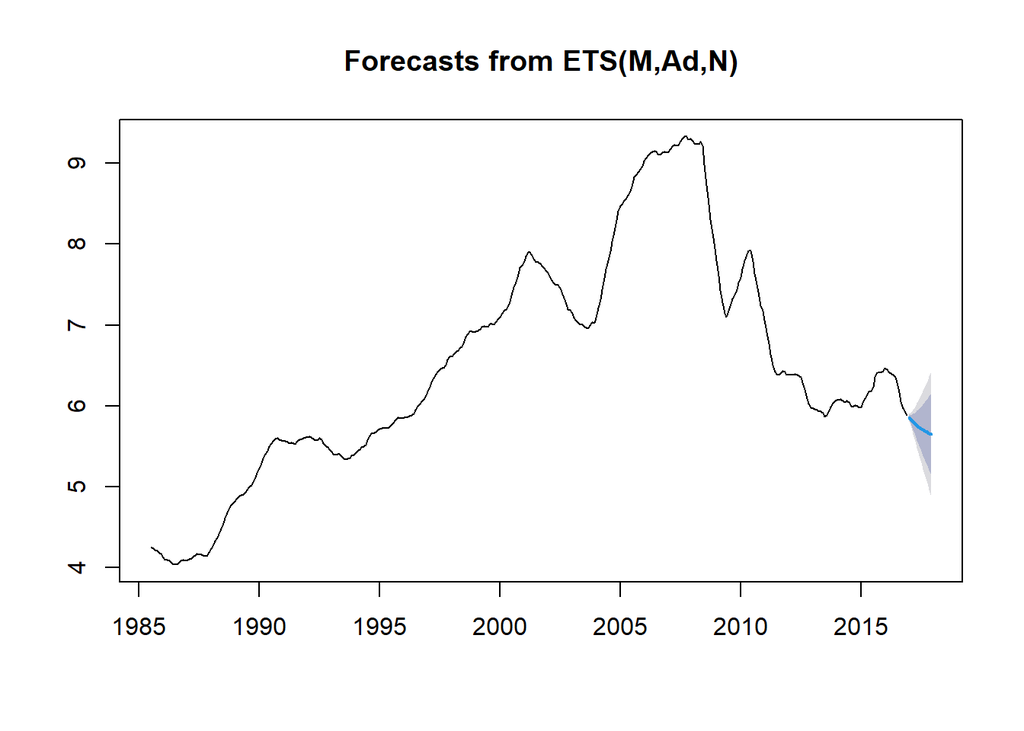

```r
plot(decomp_add_forecast)
plot(decomp_mult_forecast)
```

[output not shown]

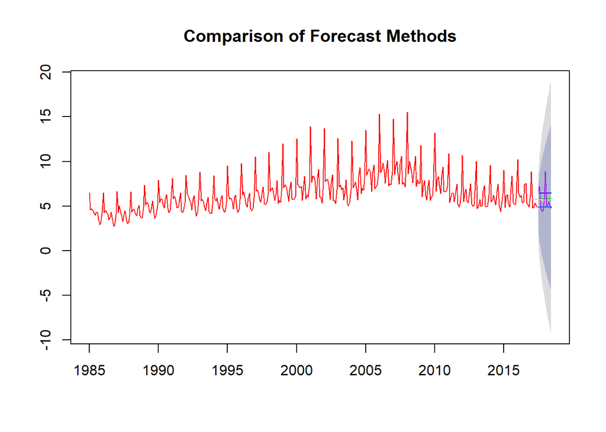

```r
mean_accuracy <- accuracy(mean_forecast)
naive_accuracy <- accuracy(naive_forecast)
ses_accuracy <- accuracy(ses_forecast)
hw_accuracy <- accuracy(hw_forecast_future)
decomp_add_accuracy <- accuracy(decomp_add_forecast)
decomp_mult_accuracy <- accuracy(decomp_mult_forecast)



plot(naive_forecast, main="Comparison of Forecast Methods", col="red")
lines(mean_forecast$mean, col="blue")
lines(ses_forecast$mean, col="green")
lines(hw_forecast_future$mean, col="purple")
lines(decomp_add_forecast$mean, col="yellow")
lines(decomp_mult_forecast$mean, col="pink")
```

Due to the trend and seasonality available in the data, MAE and MAPE would generally provide a more stable metric for accuracy. Unlike RMSE, MAE does not penalize larger errors and provides a balanced view of average error. For forecast errors in percentage terms relative to the actual values, MAPE is best forecasting technique.

8. Show model rank with accuracy measures Based on the provided accuracy measures for each model, we can rank them using the key metrics: **RMSE**, **MAE**, **MAPE**, and **MASE**. Lower values indicate better model performance.

Final Ranking of Models Based on Accuracy: 1. Decomposition (Additive and Multiplicative) - RMSE = 0.02602574 - AE = 0.01839524 - MAPE = 0.2812836 - MASE = 0.04708357

Hence, The Decomposition (Additive and Multiplicative) models rank the highest and provide the best forecast accuracy based on the given metrics. These models are likely the best choice for forecasting the next 12 months.

```r
accuracy_df <- data.frame(
  Model = c( "Additive Decomposition", "Multiplicative Decomposition","Holt-Winters", "Naive", "Mean", "Exponential Smoothing"),
ME= c( decomp_add_accuracy[1], decomp_mult_accuracy[1],hw_accuracy[1], naive_accuracy[1], mean_accuracy[1],ses_accuracy[1]),
  RMSE = c( decomp_add_accuracy[2], decomp_mult_accuracy[2],hw_accuracy[2], naive_accuracy[2], mean_accuracy[2],ses_accuracy[2]),
  MAE = c( decomp_add_accuracy[3], decomp_mult_accuracy[3],hw_accuracy[3], naive_accuracy[3], mean_accuracy[3],ses_accuracy[3]),
  MPE = c( decomp_add_accuracy[4], decomp_mult_accuracy[4],hw_accuracy[4], naive_accuracy[4], mean_accuracy[4],ses_accuracy[4]),
  MAPE = c( decomp_add_accuracy[5], decomp_mult_accuracy[5],hw_accuracy[5], naive_accuracy[5], mean_accuracy[5],ses_accuracy[5]),
  MASE = c( decomp_add_accuracy[6], decomp_mult_accuracy[6],hw_accuracy[6], naive_accuracy[6], mean_accuracy[6],ses_accuracy[6]),
  ACF1 = c( decomp_add_accuracy[7], decomp_mult_accuracy[7],hw_accuracy[7], naive_accuracy[7], mean_accuracy[7],ses_accuracy[7])
)

print(accuracy_df)
```

```
##                          Model            ME       RMSE        MAE          MPE
## 1       Additive Decomposition  2.423103e-04 0.02602574 0.01839524  0.009928876
## 2 Multiplicative Decomposition  2.423103e-04 0.02602574 0.01839524  0.009928876
## 3                 Holt-Winters  1.655382e-02 0.43233981 0.31280782  0.110415030
## 4                        Naive -4.241645e-03 2.08556300 1.39339332 -3.618636973
## 5                         Mean -3.870657e-17 2.06210502 1.54267258 -9.213308345
## 6        Exponential Smoothing  4.151457e-02 1.63422487 1.10210783 -3.784746104
##         MAPE       MASE       ACF1
## 1  0.2812836 0.04708357  0.2740217
## 2  0.2812836 0.04708357  0.2740217
## 3  4.7188366 0.59714841  0.1206157
## 4 20.3732524 2.65998017 -0.3494434
## 5 25.2711889 2.94495347  0.4891090
## 6 16.3909114 2.10391778  0.1103012
```

Given the ranking of models based on accuracy metrics (RMSE, MAE, MAPE, and MASE), I would choose Decomposition(Additive and Multiplicative) or Holt - Winters models for forecasting the next 12 months:

###Chosen Models for Forecasting: Reason: 1.Decomposition (Additive and Multiplicative): This model performed the best across all key accuracy measures (RMSE, MAE, MAPE, and MASE). The decomposition models capture both the trend and seasonality effectively, which is crucial when your data exhibits these patterns. Since the dataset has both trend and seasonality, using decomposition is ideal. As it will split the data into the trend, seasonality, and residuals, allowing us to forecast each component separately and combine them to get a more accurate overall forecast.

2.Holt-Winters: This model is also gives good accuracy. It is specifically designed for handling time series data with both trend and seasonality. The Holt-Winters model smooths out the data while accounting for both seasonal variations and any upward or downward trends. This model can directly forecast the future values by taking into account the level, trend, and seasonality in the data. Since it performed well in accuracy measures, it can be used as an alternative or to cross-check forecasts from the decomposition model.

### How I’m Going to Use These Models for Forecasting:

1. Decomposition Model:
   - First, decompose the historical time series data into its trend, seasonal, and residual components.
   - Forecast each component separately for the next 12 months.
   - Combine the forecasted trend, seasonality, and residual components to generate the final forecast for the next 12 months.
2. Holt-Winters Model:
   - Use the Holt-Winters additive or multiplicative method (depending on the data characteristics) to forecast the next 12 months.
   - Since Holt-Winters automatically handles trend and seasonality, the next 12 months’ forecast will be derived from the underlying data patterns.

#10. Provide the forecast for the next 12 months (point and range) and explain why you feel confident with these forecasts

```r
# Additive decomposition using STL
decomp_add <- stl(timeSeriesDataWindow, s.window = "periodic")
decomp_add_forecast <- forecast(decomp_add, h = 12)
print(decomp_add_forecast)
```

```
##          Point Forecast    Lo 80     Hi 80    Lo 95     Hi 95
## Jul 2017       5.708155 4.905915  6.510396 4.481235  6.935076
## Aug 2017       6.490204 5.652406  7.328003 5.208902  7.771506
## Sep 2017       4.354127 3.482220  5.226035 3.020660  5.687595
## Oct 2017       4.206009 3.301277  5.110741 2.822341  5.589677
## Nov 2017       4.278202 3.341796  5.214609 2.846093  5.710312
## Dec 2017       5.451094 4.484051  6.418138 3.972129  6.930060
## Jan 2018       9.627876 8.631136 10.624616 8.103494 11.152258
## Feb 2018       5.357905 4.332329  6.383482 3.789421  6.926389
## Mar 2018       5.723996 4.670372  6.777620 4.112617  7.335375
## Apr 2018       5.774732 4.693787  6.855676 4.121570  7.427893
## May 2018       5.143043 4.035452  6.250634 3.449129  6.836957
## Jun 2018       4.405645 3.272034  5.539256 2.671936  6.139354
```

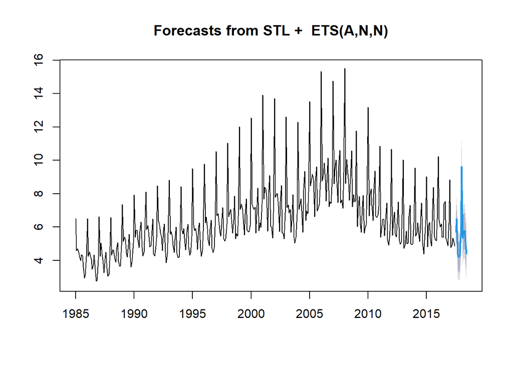

```r
plot(decomp_add_forecast)
```

```r
# Multiplicative decomposition using STL
log_flight_ts <- log(timeSeriesDataWindow)
decomp_mult <- stl(log_flight_ts, s.window = "periodic")
decomp_mult_forecast <- forecast(decomp_mult, h = 12)
decomp_mult_forecast$mean <- exp(decomp_mult_forecast$mean)
print(decomp_mult_forecast)
```

```
##          Point Forecast    Lo 80    Hi 80    Lo 95    Hi 95
## Jul 2017       5.728846 1.656162 1.834866 1.608862 1.882167
## Aug 2017       6.392077 1.753654 1.956465 1.699973 2.010145
## Sep 2017       4.590537 1.411826 1.636168 1.352447 1.695547
## Oct 2017       4.393535 1.358145 1.602124 1.293567 1.666701
## Nov 2017       4.487187 1.370151 1.632301 1.300764 1.701688
## Dec 2017       5.536090 1.571718 1.850859 1.497834 1.924743
## Jan 2018       9.087574 2.059331 2.354485 1.981208 2.432608
## Feb 2018       5.446446 1.539792 1.850135 1.457649 1.932278
## Mar 2018       5.763149 1.589073 1.913895 1.503097 1.999871
## Apr 2018       5.791797 1.587101 1.925785 1.497457 2.015429
## May 2018       5.233512 1.479083 1.831082 1.385914 1.924251
## Jun 2018       4.631314 1.350426 1.715255 1.253862 1.811820
```

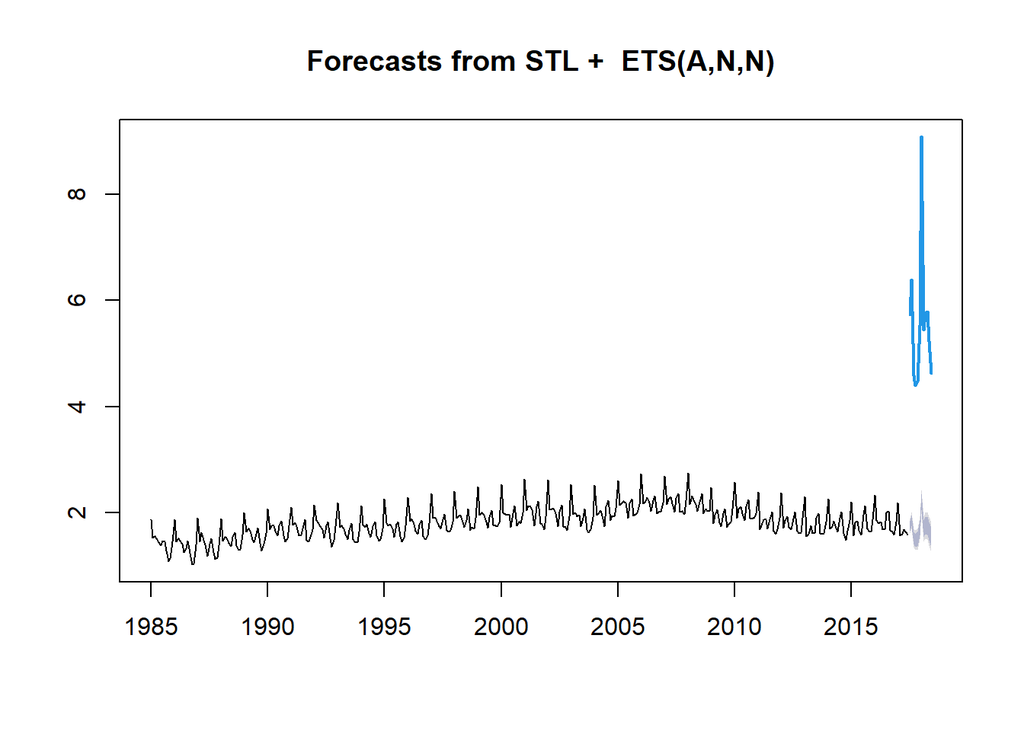

```r
plot(decomp_mult_forecast)
```